# Meeting 10 - Correlation and Regression

Matthew E. Aiello-Lammens

# Non-parametric tests

Let’s say our data don’t fit the assumptions of the *t* test. What are our options?

## Rank based tests - Mann-Whitney test

Look at ranks, rather than actual values.

From Q&K p. 47:

1. Rank all observations, ignoring groups. Tied observations get the average of their ranks.
2. Calculate the sum of the ranks for both samples. If $H_0$ is true, then you should expect similar sums.
3. Compare the smaller rank sum to the probability distribution of rank sums, based on repeated randomization of observations to groups.
4. If sample sizes are large, the probability distribution of rank sums approximates a normal distribution and the *z* statistic can be used.

## Randomization tests

Powell and Russel (1984, 1985) investigated differences in bettle consumption between two size classes of eastern horned lizards.

Get the data and look at it

```r
lizard <- read.csv(file = "https://mlammens.github.io/ENS-623-Research-Stats/data/Logan_Examples/Chapter6/Data/beetle.csv")
head(lizard)
```

```
##    SIZE BEETLES
## 1 small     256
## 2 small     209
## 3 small       0
## 4 small       0
## 5 small       0
## 6 small      44
```

```r
summary(lizard)
```

```
##     SIZE       BEETLES
##  large:21   Min.   :  0.0
##  small:24   1st Qu.:  0.0
##             Median : 34.0
##             Mean   :112.7
##             3rd Qu.:179.0
##             Max.   :843.0
```

Have a look at the box plots for these data.

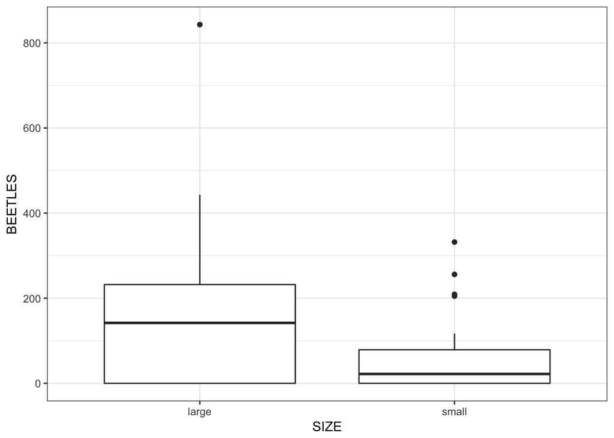

```r
library(ggplot2)

ggplot() +
  geom_boxplot(data = lizard, aes(x = SIZE, y = BEETLES) ) +
  theme_bw()
```

Let’s also look at the histograms of these data

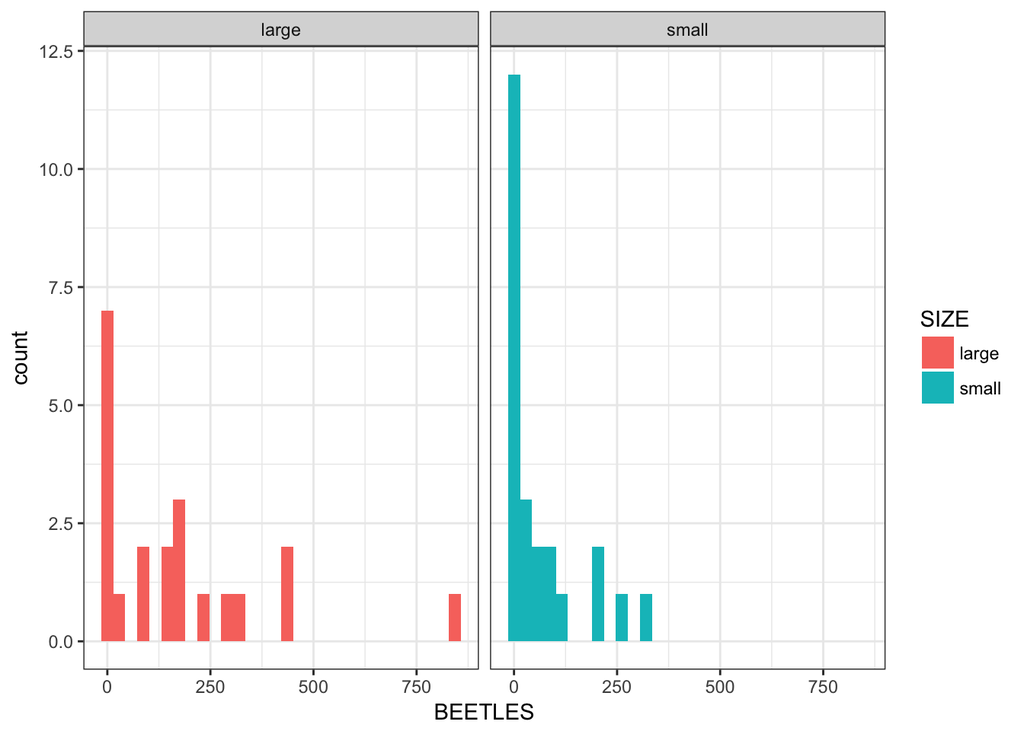

```r
ggplot() +
  geom_histogram(data = lizard, aes(x = BEETLES, fill = SIZE) ) +
  facet_grid( . ~ SIZE ) +
  theme_bw()
```

#### Challenge

What do you observe here that seems like a strong violation to the assumptions of a *t* test?

#### Major Challenge

1. Calculate the *t*-statistic for differences in number of beetles consumed by the two size classes of lizards.
2. Randomize/ shuffle the data.
3. Calculate the **new** *t*-statistic. Repeat this 999 times.
4. How does the observed *t*-stat compare to the generated *t*-stats?

```r
## Run t-test
t.test(data = lizard, BEETLES ~ SIZE)
```

```
##
##  Welch Two Sample t-test
##
## data:  BEETLES by SIZE
## t = 2.1907, df = 27.015, p-value = 0.03728
## alternative hypothesis: true difference in means is not equal to 0
## 95 percent confidence interval:
##    6.862606 209.577870
## sample estimates:
## mean in group large mean in group small
##           170.42857            62.20833
```

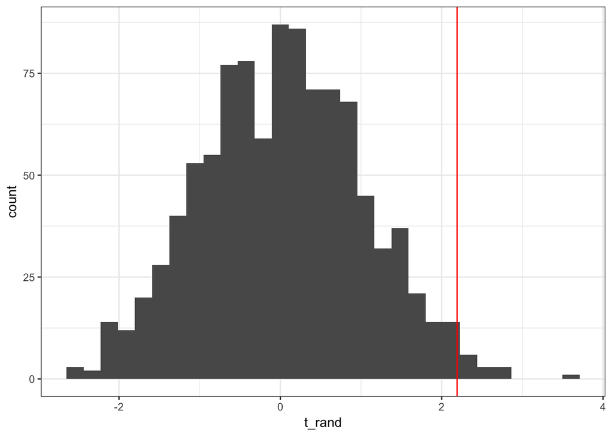

```r
## Record the original t-stat
t_orig <- t.test(data = lizard, BEETLES ~ SIZE)$statistic

## Initiate vector of new t-stat values
t_rand <- c()

## Set the number of reps (shuffles) we want to use
reps <- 1000

## Begin for loop to randomize data
for ( int in 1:reps){

  ## Shuffle the data
  lizard_shuffled <- data.frame(SIZE = sample(lizard$SIZE), BEETLES = lizard$BEETLES)

  ## Run the t-test on the new data, and save the t-stat to the t_rand vector
  t_rand <- c( t_rand,
               t.test(data = lizard_shuffled, BEETLES ~ SIZE)$statistic )

}

ggplot() +
  geom_histogram(data = NULL, aes(x = t_rand)) +
  geom_vline(xintercept = t_orig, colour = "red") +
  theme_bw()
```

To calculate how likely our original *t* statistic is, look at how many values are more extreme. Remember to check both tails.

```r
t_rand_extreme <- sum(abs(t_rand) > t_orig)

(p_t_orig <- t_rand_extreme/ reps)
```

```
## [1] 0.02
```

# Multiple testing

- If you perform a singly hypothesis test, using $\alpha = 0.05$, what is the probability that you reject the null hypothesis, even though the null is correct?
- If you perform 20 hypothesis tests, using $\alpha = 0.05$, what is the probability that in at least one of those cases, you will reject the null hypothesis, even though it is correct?

### Example of problems with multiple comparisons

```r
my_data <- list()
for (i in 1:20) {
    my_data[[i]] <- rnorm(10)  #Note the double brackets for a list
}
```

Run a *t* test for all possible pair-wise comparisons.

```r
p_vals <- matrix(ncol = 20, nrow = 20)
for (i in 1:19) {
    for (j in (i + 1):20) {
        p_vals[i, j] <- t.test(my_data[[i]], my_data[[j]])$p.value
    }
}
p_vals
```

```
##       [,1]      [,2]      [,3]      [,4]      [,5]       [,6]      [,7]
##  [1,]   NA 0.5338085 0.7030163 0.5510192 0.9787981 0.22618690 0.2579768
##  [2,]   NA        NA 0.8021567 0.2582456 0.6529965 0.56563662 0.5825617
##  [3,]   NA        NA        NA 0.3533273 0.7957129 0.40235338 0.4290081
##  [4,]   NA        NA        NA        NA 0.6358835 0.09659346 0.1188466
##  [5,]   NA        NA        NA        NA        NA 0.36242519 0.3783536
##  [6,]   NA        NA        NA        NA        NA         NA 0.9880533
##  [7,]   NA        NA        NA        NA        NA         NA        NA
##  [8,]   NA        NA        NA        NA        NA         NA        NA
##  [9,]   NA        NA        NA        NA        NA         NA        NA
## [10,]   NA        NA        NA        NA        NA         NA        NA
## [11,]   NA        NA        NA        NA        NA         NA        NA
## [12,]   NA        NA        NA        NA        NA         NA        NA
## [13,]   NA        NA        NA        NA        NA         NA        NA
## [14,]   NA        NA        NA        NA        NA         NA        NA
```

[output cut: 69 more lines]

How many are false possitives?

```r
sum(p_vals < 0.05, na.rm = TRUE)
```

```
## [1] 7
```

# Introduction to Linear Models

## Statistical Models

From Logan, p. 151:

> A **statistical model** is an expression that attempts to explain patterns in the observed values of a *response variable* by relating the response variable to a set of *predictor variables* and parameters.

A generic model looks like:

response variable = model + error

### Simple linear model

$$y = bx + a$$

where $b$ is the slope and $a$ is the y-intercept.

**Written Notes - pages 1-3**

## Co-variation

Calcualte covariation between sepal length and sepal width, using the `iris` dataset.

```r
data(iris)
head(iris)
```

```
##   Sepal.Length Sepal.Width Petal.Length Petal.Width Species
## 1          5.1         3.5          1.4         0.2  setosa
## 2          4.9         3.0          1.4         0.2  setosa
## 3          4.7         3.2          1.3         0.2  setosa
## 4          4.6         3.1          1.5         0.2  setosa
## 5          5.0         3.6          1.4         0.2  setosa
## 6          5.4         3.9          1.7         0.4  setosa
```

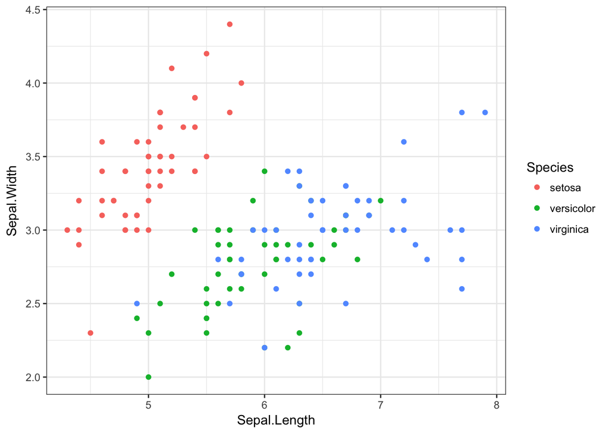

```r
library(ggplot2)
ggplot(data = iris) +
  geom_point(aes(x = Sepal.Length, y = Sepal.Width, colour = Species)) +
  theme_bw()
```

```r
covar <- sum((iris$Sepal.Length - mean(iris$Sepal.Length)) * (iris$Sepal.Width - mean(iris$Sepal.Width)))/ (nrow(iris) - 1)

## Confirm
var(x = iris$Sepal.Length, y = iris$Sepal.Width)
```

```
## [1] -0.042434
```

**Written Notes - Page 4**

## Correlation

Calculate the correlation between sepal length and sepal width, and calculate whether $r$ is significantly different from 0 or not.

```r
cor_iris <- covar / (sd(iris$Sepal.Length)*sd(iris$Sepal.Width))

se_cor_iris <- sqrt((1 - cor_iris^2)/(nrow(iris) - 2))

t_cor_iris <- cor_iris/se_cor_iris

## Calculate the probability of getting our t value, or one more extreme
pt(q = t_cor_iris, df = (nrow(iris)-2))*2
```

```
## [1] 0.1518983
```

```r
## Use `cor` to find correlation value
with(data = iris, cor(x = Sepal.Length, y = Sepal.Width, method = "pearson"))
```

```
## [1] -0.1175698
```

```r
## Test the correlation
with(data = iris, cor.test(x = Sepal.Length, y = Sepal.Width, method = "pearson"))
```

```
##
##  Pearson's product-moment correlation
##
## data:  Sepal.Length and Sepal.Width
## t = -1.4403, df = 148, p-value = 0.1519
## alternative hypothesis: true correlation is not equal to 0
## 95 percent confidence interval:
##  -0.27269325  0.04351158
## sample estimates:
##        cor
## -0.1175698
```

## Robust correlation

For Pearson’s correlation coefficient to be appropriate, the data should have:

1. A linear relationship
2. A bivariate normal distribution
- Spearman’s Rank Correlation - calculates correlation on ranks of observed values
- Kendall’s Rank Correlation